# CPE4040_Homework_5updated

## CPE 4040: Homework #5

1. Write your answer in the cell provided under each question.
2. **You must write comments to explain your thoughts and earn full credit**.
3. **Show your execution result**.
4. Do your own work. **Do not copy-and-paste other people's (or Generative AI's) codes.**

### Submission:

- **Submit this notebook file and the pdf version**

```python
import pandas as pd
import numpy as np
```

## Q1: Revisiting the Apple Store (25 Points)

#### It is time to revisit the AppleStore dataset that we worked on earlier in the semester.

#### Use what you learn from pandas, answer the following questions.

### 1. Import the dataset AppleStore.csv and assign a DataFrame called 'df_apps'.

#### How many rows and columns in the dataset? What are the row index and column labels?

#### Print the first 5 lines of the dataset.

```python
df_apps = pd.read_csv('AppleStore.csv')
```

```python
df_apps.head()
```

|  | id | track_name | size_bytes | currency | price | rating_count_tot | rating_count_ver | user_rating | user_rating_ver | ver | cont_rating | prime_genre | sup_devices.num | ipadSc_urls.num | lang.num | vpp_lic |
| --- | --- | --- | --- | --- | --- | --- | --- | --- | --- | --- | --- | --- | --- | --- | --- | --- |
| 0 | 284882215 | Facebook | 389879808 | USD | 0.0 | 2974676 | 212 | 3.5 | 3.5 | 95.0 | 4+ | Social Networking | 37 | 1 | 29 | 1 |
| 1 | 389801252 | Instagram | 113954816 | USD | 0.0 | 2161558 | 1289 | 4.5 | 4.0 | 10.23 | 12+ | Photo & Video | 37 | 0 | 29 | 1 |
| 2 | 529479190 | Clash of Clans | 116476928 | USD | 0.0 | 2130805 | 579 | 4.5 | 4.5 | 9.24.12 | 9+ | Games | 38 | 5 | 18 | 1 |
| 3 | 420009108 | Temple Run | 65921024 | USD | 0.0 | 1724546 | 3842 | 4.5 | 4.0 | 1.6.2 | 9+ | Games | 40 | 5 | 1 | 1 |
| 4 | 284035177 | Pandora - Music & Radio | 130242560 | USD | 0.0 | 1126879 | 3594 | 4.0 | 4.5 | 8.4.1 | 12+ | Music | 37 | 4 | 1 | 1 |

```python
print(f"Number of Columns: {df_apps.shape[1]}. Number of Rows: {df_apps.shape[0]}")
```

```
Number of Columns: 16. Number of Rows: 7197
```

### 2. Counting genres: how many different genres in "prime_genre"?

### How many titles are in each genre? (Hint: use value_counts method)

```python
unique_genres = df_apps["prime_genre"].nunique()
unique_genres
```

```
23
```

```python
genre_counts = df_apps["prime_genre"].value_counts()
genre_counts
```

```
prime_genre
Games                3862
Entertainment         535
Education             453
Photo & Video         349
Utilities             248
Health & Fitness      180
Productivity          178
Social Networking     167
Lifestyle             144
Music                 138
Shopping              122
Sports                114
Book                  112
Finance               104
Travel                 81
News                   75
Weather                72
Reference              64
Food & Drink           63
Business               57
Navigation             46
Medical                23
Catalogs               10
Name: count, dtype: int64
```

### 3. Content rating: how many different categories of 'content_rating'?

### What percentage of titles are in each category?

```python
unique_content_ratings = df_apps["cont_rating"].nunique()
unique_content_ratings
```

```
4
```

```python
content_rating_percentages = df_apps["cont_rating"].value_counts(normalize=True) * 100
content_rating_percentages
```

```
cont_rating
4+     61.595109
12+    16.048353
9+     13.714048
17+     8.642490
Name: proportion, dtype: float64
```

### 4. Solve a simiar problem as in Homework #3: Use GroupBy to find the distribution of rating in each genre.

#### a. How many apps in 'Games' are for age 17 and above?

#### b. How many apps in 'Education' are for kids 9 years and older?

```python
games_17_plus = df_apps[(df_apps['prime_genre'] == 'Games') & (df_apps['cont_rating'] == '17+')]


games_17_plus_count = games_17_plus.groupby(['prime_genre', 'cont_rating']).size().reset_index(name='count')

print(games_17_plus_count)
```

```
  prime_genre cont_rating  count
0       Games         17+    177
```

```python
education_9_plus = df_apps[(df_apps['prime_genre'] == 'Education') & (df_apps['cont_rating'].isin(['9+', '12+', '17+']))]


education_9_plus_count = education_9_plus.shape[0]

print(education_9_plus_count)
```

```
21
```

### 5. How many apps are free? What is the title of the most expensive app?

```python
# Calculate the number of free apps
free_apps_count = df_apps[df_apps["price"] == 0.0].shape[0]

# Find the title of the most expensive app
most_expensive_app = df_apps.loc[df_apps["price"].idxmax()]

print(free_apps_count)
print(f"The most expensive app is: {most_expensive_app['track_name']} with a price of ${most_expensive_app['price']}")
```

```
4056
The most expensive app is: LAMP Words For Life with a price of $299.99
```

## Q2: Practicing GroupBy and Data Aggregation (25 Points)

### 1. Import the dataset from the URL. This is a set of statistics of age, gender and occupation.

### How many different occupations are in the dataset?

```python
users = pd.read_table('https://raw.githubusercontent.com/justmarkham/DAT8/master/data/u.user',
                      sep='|', index_col='user_id')
```

```python
unique_occupations = users["occupation"].nunique()
print(unique_occupations)
```

```
21
```

### 2.1 There is a column label, zip_code, which will not be used in this exercise.

### Please remove the column from the DataFrame

```python
users = users.drop(columns=['zip_code'])
print(users.head())
```

```
         age gender  occupation
user_id
1         24      M  technician
2         53      F       other
3         23      M      writer
4         24      M  technician
5         33      F       other
```

### 2.2 As you may have noticed, there is an occupation called "retired".

### Please remove the users whose occupation is "retired" from the DataFrame.

```python
users_filtered = users[users["occupation"] != "retired"]
print(users_filtered.head())
```

```
         age gender  occupation
user_id
1         24      M  technician
2         53      F       other
3         23      M      writer
4         24      M  technician
5         33      F       other
```

### 3. Calculate the average age for each occupation. What are the top 5 youngest occupation groups?

### Hint: use sort_values() method.

```python
average_age_by_occupation = users_filtered.groupby("occupation")["age"].mean().sort_values()
youngest_occupations = average_age_by_occupation.head(5)

print("Top 5 youngest occupation groups:")
print(youngest_occupations)
```

```
Top 5 youngest occupation groups:
occupation
student          22.081633
none             26.555556
entertainment    29.222222
artist           31.392857
homemaker        32.571429
Name: age, dtype: float64
```

### 4. Calculate the female ratio for each occupation and sort it in ascending order.

```python
users_filtered["gender"] = users_filtered["gender"].str.strip()

occupation_counts = users_filtered.groupby("occupation")["gender"].value_counts().unstack(fill_value=0)
occupation_counts["total"] = occupation_counts.sum(axis=1)
occupation_counts["female_ratio"] = occupation_counts["F"] / occupation_counts["total"]

sorted_female_ratio = occupation_counts["female_ratio"].sort_values()

print("Female ratio for each occupation (sorted in ascending order):")
print(sorted_female_ratio)
```

```
Female ratio for each occupation (sorted in ascending order):
occupation
doctor           0.000000
engineer         0.029851
technician       0.037037
programmer       0.090909
executive        0.093750
scientist        0.096774
entertainment    0.111111
lawyer           0.166667
salesman         0.250000
educator         0.273684
student          0.306122
other            0.342857
marketing        0.384615
writer           0.422222
none             0.444444
administrator    0.455696
artist           0.464286
librarian        0.568627
healthcare       0.687500
homemaker        0.857143
Name: female_ratio, dtype: float64
```

### 5. For each occupation, calculate the minimum and maximum ages.

```python
age_stats_by_occupation = users_filtered.groupby("occupation")["age"].agg(['min', 'max'])

print("Minimum and maximum ages for each occupation:")
print(age_stats_by_occupation)
```

```
Minimum and maximum ages for each occupation:
               min  max
occupation
administrator   21   70
artist          19   48
doctor          28   64
educator        23   63
engineer        22   70
entertainment   15   50
executive       22   69
healthcare      22   62
homemaker       20   50
lawyer          21   53
librarian       23   69
marketing       24   55
none            11   55
other           13   64
programmer      20   63
salesman        18   66
scientist       23   55
student          7   42
technician      21   55
writer          18   60
```

### 6. For each combination of occupation and gender, calculate the mean age.

### Hint: This will require you to pass two column labels to Groupby.

```python
mean_age_by_occupation_gender = users_filtered.groupby(['occupation', 'gender'])['age'].mean().reset_index()
print("Mean age for each combination of occupation and gender:")
print(mean_age_by_occupation_gender)
```

```
Mean age for each combination of occupation and gender:
       occupation gender        age
0   administrator      F  40.638889
1   administrator      M  37.162791
2          artist      F  30.307692
3          artist      M  32.333333
4          doctor      M  43.571429
5        educator      F  39.115385
6        educator      M  43.101449
7        engineer      F  29.500000
8        engineer      M  36.600000
9   entertainment      F  31.000000
10  entertainment      M  29.000000
11      executive      F  44.000000
12      executive      M  38.172414
```

[output cut: 26 more lines]

## Q3: Historical Stock Prices (50 Points)

**In this exercise, you will download market data of a stock of your choice (or an index, such as Dow Jones or S&P500) and perform some exploratory data analysis (EDA).**

**You will follow the step-by-step guide in the companion Jupyter Notebook file, Homework 6 - Historical Stock data, to download the stock price data and clean up the data.**

**Please make sure to include the CSV file for the stock price data when submitting the homework.**

**NOTE: You cannot pick AAPL since it is used in the example.**

**To summarize, you will work on:**

```
1. Data cleaning
2. Simple Exploratory Data Analysis
3. 52-Week Price Range
4. Yearly Performance Summary
5. Yearly Investment Results
```

### Import the stock historical data of your choice.

```python
nvidia_df = pd.read_csv("nvidia_stock.csv")
```

### Display the first 5 rows of data

```python
nvidia_df.head()
```

|  | Date | Close/Last | Volume | Open | High | Low |
| --- | --- | --- | --- | --- | --- | --- |
| 0 | 11/12/2024 | $148.29 | 198634700 | $146.78 | $149.65 | $146.01 |
| 1 | 11/11/2024 | $145.26 | 182325600 | $148.68 | $148.85 | $143.57 |
| 2 | 11/08/2024 | $147.63 | 175665800 | $148.77 | $149.77 | $146.26 |
| 3 | 11/07/2024 | $148.88 | 207323300 | $146.39 | $148.93 | $146.17 |
| 4 | 11/06/2024 | $145.61 | 242043900 | $142.96 | $146.49 | $141.96 |

### 1. Data Cleaning Before Data Analysis

**Please follow the step-by-step guide below to clean up the data. You can refer to Step 4 in the Jupyter Notebook file, Homework 6 - Historical Stock data, to learn how to perform the task.**

### Step 1: Remove the dollar signs in the price columns and convert them to float

```python
price_columns = ["Close/Last", "Open", "High", "Low"]
for col in price_columns:
    nvidia_df[col] = nvidia_df[col].replace('[\$,]', '', regex=True).astype(float)

nvidia_df.head()
```

|  | Date | Close/Last | Volume | Open | High | Low |
| --- | --- | --- | --- | --- | --- | --- |
| 0 | 11/12/2024 | 148.29 | 198634700 | 146.78 | 149.65 | 146.01 |
| 1 | 11/11/2024 | 145.26 | 182325600 | 148.68 | 148.85 | 143.57 |
| 2 | 11/08/2024 | 147.63 | 175665800 | 148.77 | 149.77 | 146.26 |
| 3 | 11/07/2024 | 148.88 | 207323300 | 146.39 | 148.93 | 146.17 |
| 4 | 11/06/2024 | 145.61 | 242043900 | 142.96 | 146.49 | 141.96 |

### Step 2: The Date column needs to be converted to datetime format first

```python
nvidia_df['Date'] = pd.to_datetime(nvidia_df['Date'], format='%m/%d/%Y')
nvidia_df.head()
```

|  | Date | Close/Last | Volume | Open | High | Low |
| --- | --- | --- | --- | --- | --- | --- |
| 0 | 2024-11-12 | 148.29 | 198634700 | 146.78 | 149.65 | 146.01 |
| 1 | 2024-11-11 | 145.26 | 182325600 | 148.68 | 148.85 | 143.57 |
| 2 | 2024-11-08 | 147.63 | 175665800 | 148.77 | 149.77 | 146.26 |
| 3 | 2024-11-07 | 148.88 | 207323300 | 146.39 | 148.93 | 146.17 |
| 4 | 2024-11-06 | 145.61 | 242043900 | 142.96 | 146.49 | 141.96 |

### Rename the column 'Close/Last' to 'Close'

```python
nvidia_df.rename(columns = {'Close/Last':'Close'}, inplace=True)
nvidia_df.head()
```

|  | Date | Close | Volume | Open | High | Low |
| --- | --- | --- | --- | --- | --- | --- |
| 0 | 2024-11-12 | 148.29 | 198634700 | 146.78 | 149.65 | 146.01 |
| 1 | 2024-11-11 | 145.26 | 182325600 | 148.68 | 148.85 | 143.57 |
| 2 | 2024-11-08 | 147.63 | 175665800 | 148.77 | 149.77 | 146.26 |
| 3 | 2024-11-07 | 148.88 | 207323300 | 146.39 | 148.93 | 146.17 |
| 4 | 2024-11-06 | 145.61 | 242043900 | 142.96 | 146.49 | 141.96 |

### 2. Simple Exploratory Data Analysis

### Examine the column data statistics using df.describe()

```python
nvidia_df.describe()
```

|  | Date | Close | Volume | Open | High | Low |
| --- | --- | --- | --- | --- | --- | --- |
| count | 1258 | 1258.000000 | 1.258000e+03 | 1258.000000 | 1258.000000 | 1258.000000 |
| mean | 2022-05-14 17:26:13.926868224 | 34.971279 | 4.505747e+08 | 34.960976 | 35.616893 | 34.256863 |
| min | 2019-11-13 00:00:00 | 4.910000 | 9.788352e+07 | 5.002400 | 5.195500 | 4.517000 |
| 25% | 2021-02-13 00:00:00 | 13.360625 | 3.156110e+08 | 13.381575 | 13.596925 | 13.118100 |
| 50% | 2022-05-12 12:00:00 | 20.185500 | 4.254000e+08 | 20.021050 | 20.458650 | 19.791100 |
| 75% | 2023-08-14 18:00:00 | 43.514250 | 5.474608e+08 | 43.575250 | 43.984000 | 42.686750 |
| max | 2024-11-12 00:00:00 | 148.880000 | 1.543911e+09 | 148.770000 | 149.770000 | 146.260000 |
| std | NaN | 34.815174 | 1.863226e+08 | 34.839766 | 35.466812 | 34.107083 |

### Write a script to find the largest trading volumn in your dataset

```python
largest_volume = nvidia_df.loc[nvidia_df["Volume"].idxmax()]
largest_volume
```

```
Date      2023-05-25 00:00:00
Close                   37.98
Volume             1543911000
Open                   38.523
High                    39.48
Low                    36.635
Name: 369, dtype: object
```

### Write a script to find the all-time high in closing price

```python
all_time_high = nvidia_df["Close"].max()
all_time_high
```

```
148.88
```

### Which date(s) did the all-time high in closing price occur?

```python
all_time_high = nvidia_df["Close"].max()
dates_all_time_high = nvidia_df[nvidia_df["Close"] == all_time_high]["Date"]
print(dates_all_time_high)
```

```
3   2024-11-07
Name: Date, dtype: datetime64[ns]
```

### 3. The 52-Week Range

The 52-week range refers to the lowest and highest price at which a stock has traded during the previous 52 weeks. In this exercise, we consider the **intraday highs and lows**, that is, the 'High' and 'Low' columns, to find the answer.

#### Note: if the last date of your data is 2024-3-22, then the 52-week range starts at 2023-3-23 and ends at 2024-3-22.

#### Note: if your starting date falls on a non-trading day, then move the date up to the next trading day.

### Write a script to show the 52-week range.

```python
max_close = nvidia_df["Close"].max()
min_close = nvidia_df["Close"].min()

print(f"52-week range: ${min_close:.2f} - ${max_close:.2f}")
```

[output not shown]

### 4. Yearly Performance from 2014 to 2024

#### From the historical data, we can create a performance summary table for the past 10 years, such as the one shown below.

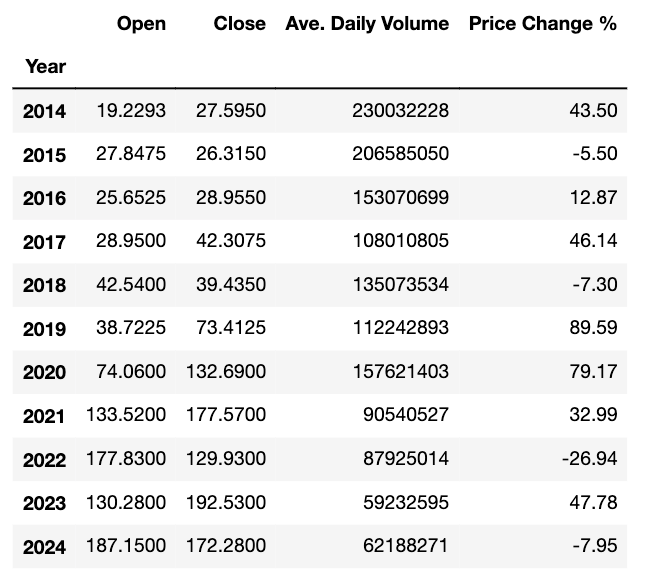

### Follow the steps below to create one for your stock.

### Step 1: Reverse the order of the DataFrame

#### The dates in the DataFrame start from the most recent date and go back in time. Let's reverse the order so the dates are in chronological order.

```python
# There are several ways to reverse a DataFrame. However, slicing is still the most effetive approach.
# df is the name of your own DataFrame.

df_rev = nvidia_df.loc[::-1].copy()
```

#### Print the first 10 rows to confirm the results.

```python
df_rev.head(10)
```

|  | Date | Close | Volume | Open | High | Low |
| --- | --- | --- | --- | --- | --- | --- |
| 1257 | 2019-11-13 | 5.2142 | 302364960 | 5.2088 | 5.2365 | 5.1475 |
| 1256 | 2019-11-14 | 5.2447 | 527006800 | 5.2233 | 5.2470 | 5.1629 |
| 1255 | 2019-11-15 | 5.1048 | 1054216400 | 5.2425 | 5.2945 | 5.0159 |
| 1254 | 2019-11-18 | 5.3070 | 575318400 | 5.0972 | 5.3338 | 5.0943 |
| 1253 | 2019-11-19 | 5.1998 | 415380400 | 5.2758 | 5.2995 | 5.1413 |
| 1252 | 2019-11-20 | 5.2795 | 473017600 | 5.1768 | 5.3638 | 5.1641 |
| 1251 | 2019-11-21 | 5.2545 | 288389200 | 5.2750 | 5.3310 | 5.2328 |
| 1250 | 2019-11-22 | 5.2722 | 224098800 | 5.2773 | 5.3241 | 5.2485 |
| 1249 | 2019-11-25 | 5.5303 | 507347600 | 5.4010 | 5.5353 | 5.3880 |
| 1248 | 2019-11-26 | 5.4250 | 385680920 | 5.5125 | 5.5172 | 5.4185 |

### Step 2: Extract the 'year' information from datetime data

#### Add a new column, 'Year', to the DataFrame. This is important for grouping by year.

```python
df_rev['Year'] = df_rev['Date'].dt.year
```

#### Print the first 10 rows of the DataFrame to confirm the results.

```python
df_rev.head(10)
```

|  | Date | Close | Volume | Open | High | Low | Year |
| --- | --- | --- | --- | --- | --- | --- | --- |
| 1257 | 2019-11-13 | 5.2142 | 302364960 | 5.2088 | 5.2365 | 5.1475 | 2019 |
| 1256 | 2019-11-14 | 5.2447 | 527006800 | 5.2233 | 5.2470 | 5.1629 | 2019 |
| 1255 | 2019-11-15 | 5.1048 | 1054216400 | 5.2425 | 5.2945 | 5.0159 | 2019 |
| 1254 | 2019-11-18 | 5.3070 | 575318400 | 5.0972 | 5.3338 | 5.0943 | 2019 |
| 1253 | 2019-11-19 | 5.1998 | 415380400 | 5.2758 | 5.2995 | 5.1413 | 2019 |
| 1252 | 2019-11-20 | 5.2795 | 473017600 | 5.1768 | 5.3638 | 5.1641 | 2019 |
| 1251 | 2019-11-21 | 5.2545 | 288389200 | 5.2750 | 5.3310 | 5.2328 | 2019 |
| 1250 | 2019-11-22 | 5.2722 | 224098800 | 5.2773 | 5.3241 | 5.2485 | 2019 |
| 1249 | 2019-11-25 | 5.5303 | 507347600 | 5.4010 | 5.5353 | 5.3880 | 2019 |
| 1248 | 2019-11-26 | 5.4250 | 385680920 | 5.5125 | 5.5172 | 5.4185 | 2019 |

### Step 3: Groupby the DataFrame by "Year"

```python
df_year = df_rev.groupby('Year')
df_year.groups.keys()
```

```
dict_keys([2019, 2020, 2021, 2022, 2023, 2024])
```

#### Please show the number of trading days for each year from 2013 to 2023.

```python
trading_days_per_year = df_rev[(df_rev['Year'] >= 2013) & (df_rev['Year'] <= 2023)]['Year'].value_counts().sort_index()
print(trading_days_per_year)
```

```
Year
2019     33
2020    253
2021    252
2022    251
2023    250
Name: count, dtype: int64
```

### Step 4: For each year, extract 'Open' price for the first trading day of the year and the 'Close' price for the last trading day of the year.

#### Note: this will require you to apply separate aggregate functions on 'Open' and 'Close' columns

```python
df_summary = df_year.agg({'Open': 'first', 'Close': 'last'})
```

#### Print the DataFrame, df_summary, to confirm the results.

```python
print(df_summary)
```

```
         Open     Close
Year
2019   5.2088    5.8825
2020   5.9688   13.0550
2021  13.1043   29.4110
2022  29.8150   14.6140
2023  14.8510   49.5220
2024  49.2440  148.2900
```

### Step 5: Add a new column, "Average Daily Volume", to df_summary, by calculating the mean of 'Volume' for each year.

#### Note: the data type of the average daily volume is integer.

```python
df_summary['Average Daily Volume'] = df_year['Volume'].mean()
```

#### Print the DataFrame, df_summary, to confirm the results.

```python
print(df_summary)
```

```
         Open     Close  Average Daily Volume
Year
2019   5.2088    5.8825          3.540595e+08
2020   5.9688   13.0550          4.809963e+08
2021  13.1043   29.4110          3.595957e+08
2022  29.8150   14.6140          5.432221e+08
2023  14.8510   49.5220          4.736280e+08
2024  49.2440  148.2900          4.021603e+08
```

### Step 6: Add another new column, "Price Change %", to df_summary, by calculating the percentage change of the stock price for each year.

#### % change = (Close - Open)/Open * 100

```python
df_summary['Price Change %'] = ((df_summary['Close'] - df_summary['Open']) / df_summary['Open']) * 100
```

#### Print the DataFrame, df_summary. This is your final performance table.

```python
print(df_summary)
```

```
         Open     Close  Average Daily Volume  Price Change %
Year
2019   5.2088    5.8825          3.540595e+08       12.933881
2020   5.9688   13.0550          4.809963e+08      118.720681
2021  13.1043   29.4110          3.595957e+08      124.437780
2022  29.8150   14.6140          5.432221e+08      -50.984404
2023  14.8510   49.5220          4.736280e+08      233.459026
2024  49.2440  148.2900          4.021603e+08      201.133133
```

### 5: Buy-and-Hold: Investment Results After 10 Years

#### Assume you invested $1,000 in the stock on the first trading date of your dataset (say, 2014-2-28) and you continued to hold the stock.

#### What are the investment values at the end of each year from 2014 to 2024?

### Step 1: Calculate the yearly cumulative return

#### Add an additional column, "Cumm Return %", to df_summary, that shows the yearly cumulative return of the stock.

```python
df_summary['Cumulative Return %'] = df_summary['Price Change %'].cumsum()
```

#### Print the DataFrame, df_summary, to show the result

```python
print(df_summary)
```

```
         Open     Close  Average Daily Volume  Price Change %  \
Year
2019   5.2088    5.8825          3.540595e+08       12.933881
2020   5.9688   13.0550          4.809963e+08      118.720681
2021  13.1043   29.4110          3.595957e+08      124.437780
2022  29.8150   14.6140          5.432221e+08      -50.984404
2023  14.8510   49.5220          4.736280e+08      233.459026
2024  49.2440  148.2900          4.021603e+08      201.133133

      Cumulative Return %
Year
2019            12.933881
2020           131.654562
2021           256.092342
2022           205.107938
2023           438.566964
2024           639.700097
```

### Step 2: Calculate the investment values

#### Using the cumulative returns, add a column, 'Investment Value', by calculating the year-end value of the initial $1,000 investment.

```python
initial_investment = 1000
df_summary['Investment Value'] = initial_investment * (1 + df_summary['Cumulative Return %'] / 100).cumprod()
```

#### Print the DataFrame, df_summary, to show the result

```python
print(df_summary)
```

```
         Open     Close  Average Daily Volume  Price Change %  \
Year
2019   5.2088    5.8825          3.540595e+08       12.933881
2020   5.9688   13.0550          4.809963e+08      118.720681
2021  13.1043   29.4110          3.595957e+08      124.437780
2022  29.8150   14.6140          5.432221e+08      -50.984404
2023  14.8510   49.5220          4.736280e+08      233.459026
2024  49.2440  148.2900          4.021603e+08      201.133133

      Cumulative Return %  Investment Value
Year
2019            12.933881      1.129339e+03
2020           131.654562      2.616165e+03
2021           256.092342      9.315963e+03
2022           205.107938      2.842374e+04
2023           438.566964      1.530809e+05
2024           639.700097      1.132339e+06
```